# AEM.00953-18 Ecological engineering helps maximize function in algal oil production.

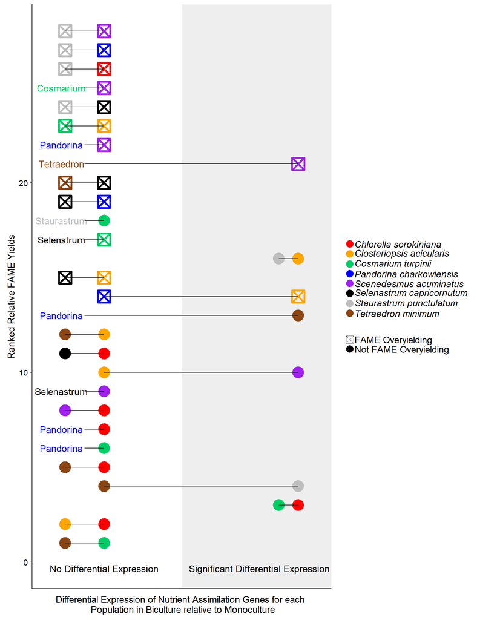

```r
 Figure.S8<-ggplot(competition.figure,aes(Nutrients_yn_simple,Ranked.Combined.Relative.FAME.log2FC))+
   geom_rect(fill = "gray92", alpha = 0.15,aes(xmin=0.05,xmax=1.0,ymin=-5,ymax=35))+
   geom_point(aes(colour=Species,size=3,shape=Overyielding.FAME,stroke=2))+
   geom_line(aes(group = combo))+
   xlab("Differential Expression of Nutrient Assimilation Genes for each \n Population in Biculture relative to Monoculture")+
   ylab("Ranked Relative FAME Yields")+
   theme(axis.text.x=element_blank(),axis.ticks.x=element_blank(),legend.text.align = 0,legend.title.align=0.5,legend.key=element_rect(fill=NA),panel.grid.major = element_blank(), panel.grid.minor = element_blank(),panel.background = element_blank(), axis.line = element_line(colour = "black"),axis.text=element_text(size = 12),axis.title=element_text(size=14,face="plain"),legend.title=element_blank(),legend.text=element_text(size=14))+
   guides(color=guide_legend(override.aes=list(size=5)),shape=guide_legend(override.aes=list(size=5)))+
   scale_shape_manual(values=c("Yes"=7,"No"=16),labels=c("Yes"= "FAME Overyielding","No"="Not FAME Overyielding"))+
   scale_colour_manual(values=c("red","orange","springgreen3","blue","purple","black","gray","chocolate4"),labels=c(my_expression1,my_expression2,my_expression3,my_expression4,my_expression5,my_expression6,my_expression7,my_expression8),name = "Species")+
   scale_size(range = c(1,10),guide="none")+
   coord_cartesian(xlim=c(-0.02,0.12), ylim=c(0.00,28))+
   annotate ("text", x = 0.01, y = 0.02, label = "\nNo Differential Expression",size=5)+
   annotate("text",x=0.09,y=0.02, label = "\nSignificant Differential Expression",size=5)+
   annotate("text",x=-0.012,y=25,label = "Cosmarium",size=5,colour="springgreen3")+
   annotate("segment", x = -0.0001, xend = 0.01, y = 25, yend = 25,colour = "black")+
   annotate("text",x=-0.012,y=22,label = "Pandorina",size=5,colour="blue")+
   annotate("segment",x = -0.0001, xend = 0.01, y = 22, yend = 22,colour = "black")+
   annotate("text",x=-0.012,y=21,label = "Tetraedron",size=5,colour="chocolate4")+
   annotate("segment", x = -0.0001, xend = 0.11, y = 21, yend = 21,colour = "black")+
   annotate("text",x=-0.012,y=18,label = "Staurastrum",size=5,colour="gray")+
   annotate("segment", x = -0.0001, xend = 0.01, y = 18, yend = 18,colour = "black")+
   annotate("text",x=-0.012,y=17,label = "Selenstrum",size=5,colour="black")+
   annotate("segment", x = -0.0001, xend = 0.01, y = 17, yend = 17,colour = "black")+
   annotate("text",x=-0.012,y=13,label = "Pandorina",size=5,colour="blue")+
   annotate("segment", x = -0.0001, xend = 0.11, y = 13, yend = 13,colour = "black")+
   annotate("text",x=-0.012,y=9,label = "Selenastrum",size=5,colour="black")+
   annotate("segment", x = -0.0001, xend = 0.01, y = 9, yend = 9,colour = "black")+
   annotate("text",x=-0.012,y=7,label = "Pandorina",size=5,colour="blue")+
   annotate("segment", x = -0.0001, xend = 0.01, y = 7, yend = 7,colour = "black")+
   annotate("text",x=-0.012,y=6,label = "Pandorina",size=5,colour="blue")+
   annotate("segment", x = -0.0001, xend = 0.01, y = 6, yend = 6,colour = "black")
 Figure.S8
```

Figure S9 The magnitude of differential expression of genes regulating nutrients assimilation and photosynthesis in biculture relative to monoculture did not significantly predict the magnitude of either FAME overyielding or total production of FAMEs (i.e., biomass multiplied by the weight percentage of FAMEs). Genes tested include: carbonic anhydrases, glutamate semialdehyde aminotransferases, light-harvesting chlorophyll a/b complexes, iron permeases, nitrite transporters, nitrite reducers, nitrate transporters, nitrate reducers, and phosphate transporters. When multiple transcripts within a species were annotated for a single function, i.e. phosphate transport, we use only the transcript with the greatest absolute value log2FC for each treatment. Note we illustrate results from two gene groups with the strongest results, but neither trend remains significant after false discovery rate correction.

```r
dat.12<-read.csv("C:/Users/Sara/Desktop/Biofuels Genomics Github/DC12vDC10_Basti.DE_results_A.csv")
dat.13<-read.csv("C:/Users/Sara/Desktop/Biofuels Genomics Github/DC13vDC10_Basti.DE_results_A.csv")
dat.14<-read.csv("C:/Users/Sara/Desktop/Biofuels Genomics Github/DC14vDC10_Basti.DE_results_A.csv")
dat.15<-read.csv("C:/Users/Sara/Desktop/Biofuels Genomics Github/DC15vDC10_Basti.DE_results_A.csv")
dat.16<-read.csv("C:/Users/Sara/Desktop/Biofuels Genomics Github/DC16vDC10_Basti.DE_results_A.csv")
dat.17<-read.csv("C:/Users/Sara/Desktop/Biofuels Genomics Github/DC17vDC10_Basti.DE_results_A.csv")
dat.18<-read.csv("C:/Users/Sara/Desktop/Biofuels Genomics Github/DC18vDC10_Basti.DE_results_A.csv")
dat.21<-read.csv("C:/Users/Sara/Desktop/Biofuels Genomics Github/DC12vDC20_Basti.DE_results_B.csv")
dat.23<-read.csv("C:/Users/Sara/Desktop/Biofuels Genomics Github/DC23vDC20_Basti.DE_results_A.csv")
dat.24<-read.csv("C:/Users/Sara/Desktop/Biofuels Genomics Github/DC24vDC20_Basti.DE_results_A.csv")
dat.25<-read.csv("C:/Users/Sara/Desktop/Biofuels Genomics Github/DC25vDC20_Basti.DE_results_A.csv")
dat.26<-read.csv("C:/Users/Sara/Desktop/Biofuels Genomics Github/DC26vDC20_Basti.DE_results_A.csv")
dat.27<-read.csv("C:/Users/Sara/Desktop/Biofuels Genomics Github/DC27vDC20_Basti.DE_results_A.csv")
dat.28<-read.csv("C:/Users/Sara/Desktop/Biofuels Genomics Github/DC28vDC20_Basti.DE_results_A.csv")
dat.31<-read.csv("C:/Users/Sara/Desktop/Biofuels Genomics Github/DC13vDC30_Basti.DE_results_B.csv")
dat.32<-read.csv("C:/Users/Sara/Desktop/Biofuels Genomics Github/DC23vDC30_Basti.DE_results_B.csv")
dat.34<-read.csv("C:/Users/Sara/Desktop/Biofuels Genomics Github/DC34vDC30_Basti.DE_results_A.csv")
dat.35<-read.csv("C:/Users/Sara/Desktop/Biofuels Genomics Github/DC35vDC30_Basti.DE_results_A.csv")
dat.36<-read.csv("C:/Users/Sara/Desktop/Biofuels Genomics Github/DC36vDC30_Basti.DE_results_A.csv")
dat.37<-read.csv("C:/Users/Sara/Desktop/Biofuels Genomics Github/DC37vDC30_Basti.DE_results_A.csv")
dat.38<-read.csv("C:/Users/Sara/Desktop/Biofuels Genomics Github/DC38vDC30_Basti.DE_results_A.csv")
dat.41<-read.csv("C:/Users/Sara/Desktop/Biofuels Genomics Github/DC14vDC40_Basti.DE_results_B.csv")
dat.42<-read.csv("C:/Users/Sara/Desktop/Biofuels Genomics Github/DC24vDC40_Basti.DE_results_B.csv")
dat.43<-read.csv("C:/Users/Sara/Desktop/Biofuels Genomics Github/DC34vDC40_Basti.DE_results_B.csv")
dat.45<-read.csv("C:/Users/Sara/Desktop/Biofuels Genomics Github/DC45vDC40_Basti.DE_results_A.csv")
dat.46<-read.csv("C:/Users/Sara/Desktop/Biofuels Genomics Github/DC46vDC40_Basti.DE_results_A.csv")
dat.47<-read.csv("C:/Users/Sara/Desktop/Biofuels Genomics Github/DC47vDC40_Basti.DE_results_A.csv")
dat.48<-read.csv("C:/Users/Sara/Desktop/Biofuels Genomics Github/DC48vDC40_Basti.DE_results_A.csv")
dat.51<-read.csv("C:/Users/Sara/Desktop/Biofuels Genomics Github/DC15vDC50_Basti.DE_results_B.csv")
dat.52<-read.csv("C:/Users/Sara/Desktop/Biofuels Genomics Github/DC25vDC50_Basti.DE_results_B.csv")
dat.53<-read.csv("C:/Users/Sara/Desktop/Biofuels Genomics Github/DC35vDC50_Basti.DE_results_B.csv")
dat.54<-read.csv("C:/Users/Sara/Desktop/Biofuels Genomics Github/DC45vDC50_Basti.DE_results_B.csv")
dat.56<-read.csv("C:/Users/Sara/Desktop/Biofuels Genomics Github/DC56vDC50_Basti.DE_results_A.csv")
dat.57<-read.csv("C:/Users/Sara/Desktop/Biofuels Genomics Github/DC57vDC50_Basti.DE_results_A.csv")
dat.58<-read.csv("C:/Users/Sara/Desktop/Biofuels Genomics Github/DC58vDC50_Basti.DE_results_A.csv")
dat.61<-read.csv("C:/Users/Sara/Desktop/Biofuels Genomics Github/DC16vDC60_Basti.DE_results_B.csv")
dat.62<-read.csv("C:/Users/Sara/Desktop/Biofuels Genomics Github/DC26vDC60_Basti.DE_results_B.csv")
dat.63<-read.csv("C:/Users/Sara/Desktop/Biofuels Genomics Github/DC36vDC60_Basti.DE_results_B.csv")
dat.64<-read.csv("C:/Users/Sara/Desktop/Biofuels Genomics Github/DC46vDC60_Basti.DE_results_B.csv")
dat.65<-read.csv("C:/Users/Sara/Desktop/Biofuels Genomics Github/DC56vDC60_Basti.DE_results_B.csv")
dat.67<-read.csv("C:/Users/Sara/Desktop/Biofuels Genomics Github/DC67vDC60_Basti.DE_results_A.csv")
dat.68<-read.csv("C:/Users/Sara/Desktop/Biofuels Genomics Github/DC68vDC60_Basti.DE_results_A.csv")
dat.71<-read.csv("C:/Users/Sara/Desktop/Biofuels Genomics Github/DC17vDC70_Basti.DE_results_B.csv")
dat.72<-read.csv("C:/Users/Sara/Desktop/Biofuels Genomics Github/DC27vDC70_Basti.DE_results_B.csv")
dat.73<-read.csv("C:/Users/Sara/Desktop/Biofuels Genomics Github/DC37vDC70_Basti.DE_results_B.csv")
dat.74<-read.csv("C:/Users/Sara/Desktop/Biofuels Genomics Github/DC47vDC70_Basti.DE_results_B.csv")
dat.75<-read.csv("C:/Users/Sara/Desktop/Biofuels Genomics Github/DC57vDC70_Basti.DE_results_B.csv")
dat.76<-read.csv("C:/Users/Sara/Desktop/Biofuels Genomics Github/DC67vDC70_Basti.DE_results_B.csv")
dat.78<-read.csv("C:/Users/Sara/Desktop/Biofuels Genomics Github/DC78vDC70_Basti.DE_results_A.csv")
dat.81<-read.csv("C:/Users/Sara/Desktop/Biofuels Genomics Github/DC18vDC80_Basti.DE_results_B.csv")
dat.82<-read.csv("C:/Users/Sara/Desktop/Biofuels Genomics Github/DC28vDC80_Basti.DE_results_B.csv")
dat.83<-read.csv("C:/Users/Sara/Desktop/Biofuels Genomics Github/DC38vDC80_Basti.DE_results_B.csv")
dat.84<-read.csv("C:/Users/Sara/Desktop/Biofuels Genomics Github/DC48vDC80_Basti.DE_results_B.csv")
dat.85<-read.csv("C:/Users/Sara/Desktop/Biofuels Genomics Github/DC58vDC80_Basti.DE_results_B.csv")
dat.86<-read.csv("C:/Users/Sara/Desktop/Biofuels Genomics Github/DC68vDC80_Basti.DE_results_B.csv")
dat.87<-read.csv("C:/Users/Sara/Desktop/Biofuels Genomics Github/DC78vDC80_Basti.DE_results_B.csv")

data<-rbind(dat.12,dat.13,dat.14,dat.15,dat.16,dat.17,dat.18,dat.21,dat.23,dat.24,dat.25,dat.26,dat.27,dat.28,dat.31,dat.32,dat.34,dat.35,dat.36,dat.37,dat.38,dat.41,dat.42,dat.43,dat.45,dat.46,dat.47,dat.48,dat.51,dat.52,dat.53,dat.54,dat.56,dat.57,dat.58,dat.61,dat.62,dat.63,dat.64,dat.65,dat.67,dat.68,dat.71,dat.72,dat.73,dat.74,dat.75,dat.76,dat.78,dat.81,dat.82,dat.83,dat.84,dat.85,dat.86,dat.87)
data$biculture.simple<-data$Species
data$Species<-NULL
competition_figure_for_genes<-read.csv("C:/Users/Sara/Desktop/Biofuels Genomics Github/Competition.figure.csv")
data<-dplyr::full_join(data,competition_figure_for_genes,by='biculture.simple')
data<-data[!is.na(data$biculture),]

CarbonicAnhydrase.data<-data[(data$Function=="CarbonicAnhydrase"),]
CarbonicAnhydrase.data <- CarbonicAnhydrase.data[order(CarbonicAnhydrase.data$biculture.simple, -abs(CarbonicAnhydrase.data$logFC) ), ]
CarbonicAnhydrase.data<-CarbonicAnhydrase.data[ !duplicated(CarbonicAnhydrase.data$biculture.simple), ]

IronPermease.data<-data[(data$Function=="IronPermease"),]
IronPermease.data <- IronPermease.data[order(IronPermease.data$biculture.simple, -abs(IronPermease.data$logFC) ), ]
IronPermease.data<-IronPermease.data[ !duplicated(IronPermease.data$biculture.simple), ]

LHCAB.data<-data[(data$Function=="LHCAB"),]
LHCAB.data <- LHCAB.data[order(LHCAB.data$biculture.simple, -abs(LHCAB.data$logFC) ), ]
LHCAB.data<-LHCAB.data[ !duplicated(LHCAB.data$biculture.simple), ]

NitrateReductase.data<-data[(data$Function=="NitrateReductase"),]
NitrateReductase.data <- NitrateReductase.data[order(NitrateReductase.data$biculture.simple, -abs(NitrateReductase.data$logFC) ), ]
NitrateReductase.data<-NitrateReductase.data[ !duplicated(NitrateReductase.data$biculture.simple), ]

NitrateTransporter.data<-data[(data$Function=="NitrateTransporter"),]
NitrateTransporter.data <- NitrateTransporter.data[order(NitrateTransporter.data$biculture.simple, -abs(NitrateTransporter.data$logFC) ), ]
NitrateTransporter.data<-NitrateTransporter.data[ !duplicated(NitrateTransporter.data$biculture.simple), ]

NitriteReductase.data<-data[(data$Function=="NitriteReductase"),]
NitriteReductase.data <- NitriteReductase.data[order(NitriteReductase.data$biculture.simple, -abs(NitriteReductase.data$logFC) ), ]
NitriteReductase.data<-NitriteReductase.data[ !duplicated(NitriteReductase.data$biculture.simple), ]

NitriteTransporter.data<-data[(data$Function=="NitriteTransporter"),]
NitriteTransporter.data <- NitriteTransporter.data[order(NitriteTransporter.data$biculture.simple, -abs(NitriteTransporter.data$logFC) ), ]
NitriteTransporter.data<-NitriteTransporter.data[ !duplicated(NitriteTransporter.data$biculture.simple), ]

PhosphateTransporter.data<-data[(data$Function=="PhosphateTransporter"),]
PhosphateTransporter.data <- PhosphateTransporter.data[order(PhosphateTransporter.data$biculture.simple, -abs(PhosphateTransporter.data$logFC) ), ]
PhosphateTransporter.data<-PhosphateTransporter.data[ !duplicated(PhosphateTransporter.data$biculture.simple), ]

GlutamateSemialdehydeAmintransferase.data<-data[(data$Function=="GlutamateSemialdehydeAmintransferase"),]
GlutamateSemialdehydeAmintransferase.data <- GlutamateSemialdehydeAmintransferase.data[order(GlutamateSemialdehydeAmintransferase.data$biculture.simple, -abs(GlutamateSemialdehydeAmintransferase.data$logFC) ), ] #sort by id and reverse of abs(value)
GlutamateSemialdehydeAmintransferase.data<-GlutamateSemialdehydeAmintransferase.data[ !duplicated(GlutamateSemialdehydeAmintransferase.data$biculture.simple), ]

summary(lm(log2FC.Total.Biomass.x.FAMEs~logFC,data=CarbonicAnhydrase.data))
```

```
##
## Call:
## lm(formula = log2FC.Total.Biomass.x.FAMEs ~ logFC, data = CarbonicAnhydrase.data)
##
## Residuals:
##     Min      1Q  Median      3Q     Max
## -1.8221 -0.6809  0.0641  0.4371  4.7149
##
## Coefficients:
##             Estimate Std. Error t value Pr(>|t|)
## (Intercept)  0.35203    0.19305   1.823   0.0759 .
## logFC       -0.07973    0.14110  -0.565   0.5753
## ---
## Signif. codes:  0 '***' 0.001 '**' 0.01 '*' 0.05 '.' 0.1 ' ' 1
##
## Residual standard error: 1.171 on 39 degrees of freedom
## Multiple R-squared:  0.008121,   Adjusted R-squared:  -0.01731
## F-statistic: 0.3193 on 1 and 39 DF,  p-value: 0.5753
```

```r
summary(lm(log2FC.Total.Biomass.x.FAMEs~logFC,data=IronPermease.data))
```

```
##
## Call:
## lm(formula = log2FC.Total.Biomass.x.FAMEs ~ logFC, data = IronPermease.data)
##
## Residuals:
##     Min      1Q  Median      3Q     Max
## -1.8253 -0.7275 -0.0018  0.4385  4.6824
##
## Coefficients:
##             Estimate Std. Error t value Pr(>|t|)
## (Intercept)  0.43276    0.21025   2.058   0.0475 *
## logFC        0.01276    0.11680   0.109   0.9137
## ---
## Signif. codes:  0 '***' 0.001 '**' 0.01 '*' 0.05 '.' 0.1 ' ' 1
##
## Residual standard error: 1.231 on 33 degrees of freedom
## Multiple R-squared:  0.0003613,  Adjusted R-squared:  -0.02993
## F-statistic: 0.01193 on 1 and 33 DF,  p-value: 0.9137
```

```r
summary(lm(log2FC.Total.Biomass.x.FAMEs~logFC,data=LHCAB.data))
```

```
##
## Call:
## lm(formula = log2FC.Total.Biomass.x.FAMEs ~ logFC, data = LHCAB.data)
##
## Residuals:
##     Min      1Q  Median      3Q     Max
## -1.9568 -0.5446  0.0606  0.4210  4.4967
##
## Coefficients:
##             Estimate Std. Error t value Pr(>|t|)
## (Intercept)  0.49065    0.17096   2.870  0.00623 **
## logFC        0.06225    0.05397   1.153  0.25485
## ---
## Signif. codes:  0 '***' 0.001 '**' 0.01 '*' 0.05 '.' 0.1 ' ' 1
##
## Residual standard error: 1.146 on 45 degrees of freedom
## Multiple R-squared:  0.02871,    Adjusted R-squared:  0.007129
## F-statistic:  1.33 on 1 and 45 DF,  p-value: 0.2548
```

```r
summary(lm(log2FC.Total.Biomass.x.FAMEs~logFC,data=NitrateReductase.data))
```

```
##
## Call:
## lm(formula = log2FC.Total.Biomass.x.FAMEs ~ logFC, data = NitrateReductase.data)
##
## Residuals:
##     Min      1Q  Median      3Q     Max
## -1.8154 -0.5964  0.0040  0.4356  4.6757
##
## Coefficients:
##             Estimate Std. Error t value Pr(>|t|)
## (Intercept)  0.43981    0.17112   2.570   0.0135 *
## logFC        0.02417    0.06384   0.379   0.7067
## ---
## Signif. codes:  0 '***' 0.001 '**' 0.01 '*' 0.05 '.' 0.1 ' ' 1
##
## Residual standard error: 1.161 on 45 degrees of freedom
## Multiple R-squared:  0.003177,   Adjusted R-squared:  -0.01897
## F-statistic: 0.1434 on 1 and 45 DF,  p-value: 0.7067
```

```r
summary(lm(log2FC.Total.Biomass.x.FAMEs~logFC,data=NitrateTransporter.data))
```

```
##
## Call:
## lm(formula = log2FC.Total.Biomass.x.FAMEs ~ logFC, data = NitrateTransporter.data)
##
## Residuals:
##     Min      1Q  Median      3Q     Max
## -1.9108 -0.6562 -0.0219  0.4421  4.2761
##
## Coefficients:
##             Estimate Std. Error t value Pr(>|t|)
## (Intercept)  0.44029    0.16523   2.665   0.0107 *
## logFC        0.08010    0.05105   1.569   0.1237
## ---
## Signif. codes:  0 '***' 0.001 '**' 0.01 '*' 0.05 '.' 0.1 ' ' 1
##
## Residual standard error: 1.132 on 45 degrees of freedom
## Multiple R-squared:  0.05186,    Adjusted R-squared:  0.03079
## F-statistic: 2.461 on 1 and 45 DF,  p-value: 0.1237
```

```r
summary(lm(log2FC.Total.Biomass.x.FAMEs~logFC,data=NitriteReductase.data))
```

```
##
## Call:
## lm(formula = log2FC.Total.Biomass.x.FAMEs ~ logFC, data = NitriteReductase.data)
##
## Residuals:
##      Min       1Q   Median       3Q      Max
## -1.83170 -0.39149  0.08768  0.42178  1.74071
##
## Coefficients:
##             Estimate Std. Error t value Pr(>|t|)
## (Intercept)  0.47940    0.16577   2.892  0.00694 **
## logFC        0.03660    0.05432   0.674  0.50550
## ---
## Signif. codes:  0 '***' 0.001 '**' 0.01 '*' 0.05 '.' 0.1 ' ' 1
##
## Residual standard error: 0.9491 on 31 degrees of freedom
## Multiple R-squared:  0.01443,    Adjusted R-squared:  -0.01736
## F-statistic: 0.4539 on 1 and 31 DF,  p-value: 0.5055
```

```r
summary(lm(log2FC.Total.Biomass.x.FAMEs~logFC,data=NitriteTransporter.data))
```

```
##
## Call:
## lm(formula = log2FC.Total.Biomass.x.FAMEs ~ logFC, data = NitriteTransporter.data)
##
## Residuals:
##     Min      1Q  Median      3Q     Max
## -1.7476 -0.6728  0.0400  0.3847  4.8026
##
## Coefficients:
##             Estimate Std. Error t value Pr(>|t|)
## (Intercept)  0.26121    0.19798   1.319    0.195
## logFC        0.12742    0.08629   1.477    0.148
##
## Residual standard error: 1.145 on 39 degrees of freedom
## Multiple R-squared:  0.05295,    Adjusted R-squared:  0.02867
## F-statistic: 2.181 on 1 and 39 DF,  p-value: 0.1478
```

```r
summary(lm(log2FC.Total.Biomass.x.FAMEs~logFC,data=GlutamateSemialdehydeAmintransferase.data))
```

```
##
## Call:
## lm(formula = log2FC.Total.Biomass.x.FAMEs ~ logFC, data = GlutamateSemialdehydeAmintransferase.data)
##
## Residuals:
##     Min      1Q  Median      3Q     Max
## -1.7888 -0.4669  0.0821  0.4063  4.5410
##
## Coefficients:
##             Estimate Std. Error t value Pr(>|t|)
## (Intercept)   0.3712     0.2102   1.766   0.0861 .
## logFC         0.1408     0.1522   0.925   0.3611
## ---
## Signif. codes:  0 '***' 0.001 '**' 0.01 '*' 0.05 '.' 0.1 ' ' 1
##
## Residual standard error: 1.174 on 35 degrees of freedom
## Multiple R-squared:  0.02389,    Adjusted R-squared:  -0.004002
## F-statistic: 0.8565 on 1 and 35 DF,  p-value: 0.3611
```

```r
summary(lm(log2FC.Total.Biomass.x.FAMEs~logFC,data=PhosphateTransporter.data))
```

```
##
## Call:
## lm(formula = log2FC.Total.Biomass.x.FAMEs ~ logFC, data = PhosphateTransporter.data)
##
## Residuals:
##     Min      1Q  Median      3Q     Max
## -1.9811 -0.6939  0.0212  0.4896  4.0044
##
## Coefficients:
##             Estimate Std. Error t value Pr(>|t|)
## (Intercept)  0.29748    0.17413   1.708   0.0945 .
## logFC        0.10344    0.04573   2.262   0.0286 *
## ---
## Signif. codes:  0 '***' 0.001 '**' 0.01 '*' 0.05 '.' 0.1 ' ' 1
##
## Residual standard error: 1.102 on 45 degrees of freedom
## Multiple R-squared:  0.1021, Adjusted R-squared:  0.08215
## F-statistic: 5.117 on 1 and 45 DF,  p-value: 0.02857
```

```r
PhosphateTransporter.plot<-ggplot(PhosphateTransporter.data,aes(logFC,log2FC.Total.Biomass.x.FAMEs))+
  geom_point(aes(colour=factor(Species),size=3)) +
  theme(legend.text.align = 0,legend.key=element_rect(fill=NA),panel.grid.major = element_blank(), panel.grid.minor = element_blank(),panel.background = element_blank(), axis.line = element_line(colour = "black"),axis.text=element_text(size = 12),axis.title=element_text(size=14,face="plain"),legend.title=element_text(size=12),legend.text=element_text(size=12))+
  xlab("Phosphate Transporter Genes (Log2FC)")+
  ylab("Total FAMEs (Biomass x wt % FAMEs)  (Log2FC)")+
  scale_colour_manual(guide="none","Algal Species",labels=c(my_expression3,my_expression7,my_expression8),values=c("red","orange","springgreen3","blue","purple","black","gray","chocolate4"))+
  #scale_shape_manual(guide="none","FAME Overyielding",labels=c("Not Overyielding","Overyielding"),values=c(16,7))+
  scale_size(guide="none")+
  annotate("text", x=-12, y=5,label=paste("list(R^{2}==8.2~p==0.029)"),parse=TRUE,hjust=0.0,size=5)

summary(lm(Combined.Relative.FAME.log2FC~logFC,data=CarbonicAnhydrase.data))
```

```
##
## Call:
## lm(formula = Combined.Relative.FAME.log2FC ~ logFC, data = CarbonicAnhydrase.data)
##
## Residuals:
##     Min      1Q  Median      3Q     Max
## -0.6731 -0.3081  0.0375  0.3643  0.8043
##
## Coefficients:
##             Estimate Std. Error t value Pr(>|t|)
## (Intercept)  0.21697    0.06709   3.234  0.00249 **
## logFC        0.06079    0.04904   1.240  0.22248
## ---
## Signif. codes:  0 '***' 0.001 '**' 0.01 '*' 0.05 '.' 0.1 ' ' 1
##
## Residual standard error: 0.4071 on 39 degrees of freedom
## Multiple R-squared:  0.03791,    Adjusted R-squared:  0.01325
## F-statistic: 1.537 on 1 and 39 DF,  p-value: 0.2225
```

```r
summary(lm(Combined.Relative.FAME.log2FC~logFC,data=LHCAB.data))
```

```
##
## Call:
## lm(formula = Combined.Relative.FAME.log2FC ~ logFC, data = LHCAB.data)
##
## Residuals:
##      Min       1Q   Median       3Q      Max
## -0.82900 -0.25329  0.06008  0.30013  0.76022
##
## Coefficients:
##             Estimate Std. Error t value Pr(>|t|)
## (Intercept)  0.22141    0.06403   3.458   0.0012 **
## logFC       -0.02189    0.02021  -1.083   0.2845
## ---
## Signif. codes:  0 '***' 0.001 '**' 0.01 '*' 0.05 '.' 0.1 ' ' 1
##
## Residual standard error: 0.4291 on 45 degrees of freedom
## Multiple R-squared:  0.02541,    Adjusted R-squared:  0.003752
## F-statistic: 1.173 on 1 and 45 DF,  p-value: 0.2845
```

```r
summary(lm(Combined.Relative.FAME.log2FC~logFC,data=PhosphateTransporter.data))
```

```
##
## Call:
## lm(formula = Combined.Relative.FAME.log2FC ~ logFC, data = PhosphateTransporter.data)
##
## Residuals:
##      Min       1Q   Median       3Q      Max
## -0.83231 -0.28489  0.05636  0.29282  0.65917
##
## Coefficients:
##             Estimate Std. Error t value Pr(>|t|)
## (Intercept)  0.27393    0.06712   4.081 0.000181 ***
## logFC       -0.02587    0.01763  -1.468 0.149177
## ---
## Signif. codes:  0 '***' 0.001 '**' 0.01 '*' 0.05 '.' 0.1 ' ' 1
##
## Residual standard error: 0.4246 on 45 degrees of freedom
## Multiple R-squared:  0.04568,    Adjusted R-squared:  0.02447
## F-statistic: 2.154 on 1 and 45 DF,  p-value: 0.1492
```

```r
summary(lm(Combined.Relative.FAME.log2FC~logFC,data=NitrateReductase.data))
```

```
##
## Call:
## lm(formula = Combined.Relative.FAME.log2FC ~ logFC, data = NitrateReductase.data)
##
## Residuals:
##      Min       1Q   Median       3Q      Max
## -0.80860 -0.26901  0.06743  0.33507  0.71326
##
## Coefficients:
##             Estimate Std. Error t value Pr(>|t|)
## (Intercept)  0.24213    0.06377   3.797 0.000436 ***
## logFC       -0.01581    0.02379  -0.665 0.509748
## ---
## Signif. codes:  0 '***' 0.001 '**' 0.01 '*' 0.05 '.' 0.1 ' ' 1
##
## Residual standard error: 0.4326 on 45 degrees of freedom
## Multiple R-squared:  0.009718,   Adjusted R-squared:  -0.01229
## F-statistic: 0.4416 on 1 and 45 DF,  p-value: 0.5097
```

```r
summary(lm(Combined.Relative.FAME.log2FC~logFC,data=NitrateTransporter.data))
```

```
##
## Call:
## lm(formula = Combined.Relative.FAME.log2FC ~ logFC, data = NitrateTransporter.data)
##
## Residuals:
##      Min       1Q   Median       3Q      Max
## -0.80851 -0.24558  0.05946  0.33126  0.67804
##
## Coefficients:
##              Estimate Std. Error t value Pr(>|t|)
## (Intercept)  0.236955   0.063304   3.743 0.000514 ***
## logFC       -0.008688   0.019560  -0.444 0.659047
## ---
## Signif. codes:  0 '***' 0.001 '**' 0.01 '*' 0.05 '.' 0.1 ' ' 1
##
## Residual standard error: 0.4337 on 45 degrees of freedom
## Multiple R-squared:  0.004365,   Adjusted R-squared:  -0.01776
## F-statistic: 0.1973 on 1 and 45 DF,  p-value: 0.659
```

```r
summary(lm(Combined.Relative.FAME.log2FC~logFC,data=NitriteReductase.data))
```

```
##
## Call:
## lm(formula = Combined.Relative.FAME.log2FC ~ logFC, data = NitriteReductase.data)
##
## Residuals:
##      Min       1Q   Median       3Q      Max
## -0.77674 -0.46907  0.07285  0.35056  0.68079
##
## Coefficients:
##             Estimate Std. Error t value Pr(>|t|)
## (Intercept)  0.20653    0.08115   2.545   0.0161 *
## logFC       -0.01266    0.02659  -0.476   0.6373
## ---
## Signif. codes:  0 '***' 0.001 '**' 0.01 '*' 0.05 '.' 0.1 ' ' 1
##
## Residual standard error: 0.4646 on 31 degrees of freedom
## Multiple R-squared:  0.007262,   Adjusted R-squared:  -0.02476
## F-statistic: 0.2268 on 1 and 31 DF,  p-value: 0.6373
```

```r
summary(lm(Combined.Relative.FAME.log2FC~logFC,data=NitriteTransporter.data))
```

```
##
## Call:
## lm(formula = Combined.Relative.FAME.log2FC ~ logFC, data = NitriteTransporter.data)
##
## Residuals:
##      Min       1Q   Median       3Q      Max
## -0.75991 -0.22002  0.07924  0.34178  0.71694
##
## Coefficients:
##             Estimate Std. Error t value Pr(>|t|)
## (Intercept)  0.20168    0.07166   2.814  0.00762 **
## logFC       -0.01143    0.03124  -0.366  0.71634
## ---
## Signif. codes:  0 '***' 0.001 '**' 0.01 '*' 0.05 '.' 0.1 ' ' 1
##
## Residual standard error: 0.4143 on 39 degrees of freedom
## Multiple R-squared:  0.003423,   Adjusted R-squared:  -0.02213
## F-statistic: 0.134 on 1 and 39 DF,  p-value: 0.7163
```

```r
summary(lm(Combined.Relative.FAME.log2FC~logFC,data=GlutamateSemialdehydeAmintransferase.data))
```

```
##
## Call:
## lm(formula = Combined.Relative.FAME.log2FC ~ logFC, data = GlutamateSemialdehydeAmintransferase.data)
##
## Residuals:
##      Min       1Q   Median       3Q      Max
## -0.86244 -0.22974  0.06312  0.26059  0.69576
##
## Coefficients:
##             Estimate Std. Error t value Pr(>|t|)
## (Intercept)  0.24108    0.07619   3.164  0.00321 **
## logFC        0.03136    0.05517   0.569  0.57332
## ---
## Signif. codes:  0 '***' 0.001 '**' 0.01 '*' 0.05 '.' 0.1 ' ' 1
##
## Residual standard error: 0.4257 on 35 degrees of freedom
## Multiple R-squared:  0.00915,    Adjusted R-squared:  -0.01916
## F-statistic: 0.3232 on 1 and 35 DF,  p-value: 0.5733
```

```r
summary(lm(Combined.Relative.FAME.log2FC~logFC,data=IronPermease.data))
```

```
##
## Call:
## lm(formula = Combined.Relative.FAME.log2FC ~ logFC, data = IronPermease.data)
##
## Residuals:
##      Min       1Q   Median       3Q      Max
## -0.73095 -0.25863 -0.02403  0.24903  0.84242
##
## Coefficients:
##             Estimate Std. Error t value Pr(>|t|)
## (Intercept)  0.19741    0.06582   2.999  0.00512 **
## logFC        0.06696    0.03657   1.831  0.07610 .
## ---
## Signif. codes:  0 '***' 0.001 '**' 0.01 '*' 0.05 '.' 0.1 ' ' 1
##
## Residual standard error: 0.3855 on 33 degrees of freedom
## Multiple R-squared:  0.09225,    Adjusted R-squared:  0.06474
## F-statistic: 3.354 on 1 and 33 DF,  p-value: 0.0761
```

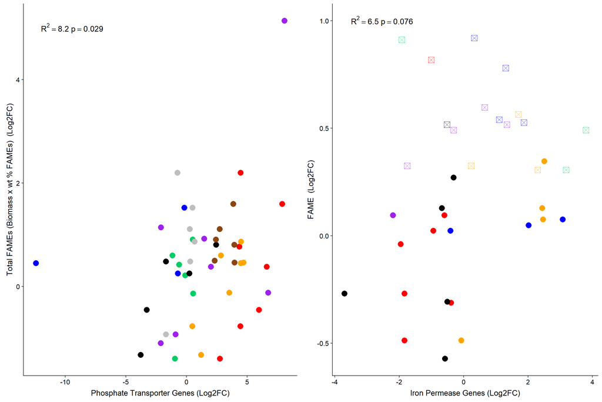

```r
IronPermease.data.plot<-ggplot(IronPermease.data,aes(logFC,Combined.Relative.FAME.log2FC))+
  geom_point(aes(colour=factor(Species),shape=Overyielding.FAME,size=3)) +
  theme(legend.text.align = 0,legend.key=element_rect(fill=NA),panel.grid.major = element_blank(), panel.grid.minor = element_blank(),panel.background = element_blank(), axis.line = element_line(colour = "black"),axis.text=element_text(size = 12),axis.title=element_text(size=14,face="plain"),legend.title=element_text(size=12),legend.text=element_text(size=12))+
  xlab("Iron Permease Genes (Log2FC)")+
  ylab("FAME  (Log2FC)")+
  scale_colour_manual(guide="none","Algal Species",labels=c(my_expression3,my_expression7,my_expression8),values=c("red","orange","springgreen3","blue","purple","black","gray","chocolate4"))+
  scale_shape_manual(guide="none","FAME Overyielding",labels=c("Not Overyielding","Overyielding"),values=c(16,7))+
  scale_size(guide="none")+
  annotate("text", x=-3.5, y=1,label=paste("list(R^{2}==6.5~p==0.076)"),parse=TRUE,hjust=0.0,size=5)

Figure.S9<-plot_grid(PhosphateTransporter.plot,IronPermease.data.plot)
Figure.S9
```